# notes_2407270650

## 读《怎样解题：数学思维的新方法》波利亚 著

这本书第一版出版于 1944 年，时至今日，依然是数学思维领域，帮助人入门的首选书籍。这本书的作者波利亚成长的环境，是匈牙利，在他所生活的年代，匈牙利出现了很多的享誉世界的数学家。而希尔伯特、冯诺依曼、爱因斯坦等人都有广泛的交集合作，一些大学，比如苏黎世联邦理工大学成为了数学精英云集的地方。

为什么密集的出现这么多数学精英呢？**有一个为人关注的地方，那就是匈牙利的教育制度，就是从娃娃开始，通过竞赛的形式寻找有数学能力优秀的人，从小开始给与特殊的照顾。**

**波利亚的《怎样解题》，不但是教会读者如何的解题，同时也是面向数学老师。文中很多篇幅是，如何成为一名合格的数学老师。**

作者简介：波利亚（George Polya，1887~1985），著名美国数学家和数学教育家。生于匈牙利布达佩斯。1912年获布达佩斯大学博士学位。1914年至1940年在瑞士苏黎世工业大学任数学助理教授、副教授和教授，1928年后任数学系主任。1940年移居美国，历任布朗大学和斯坦福大学的教授。1976年当选美国国家科学院院士。还是匈牙利科学院、法兰西科学院、比利时布鲁塞尔国际哲学科学院和美国艺术和科学学院的院士。其数学研究涉及复变函数、概率论、数论、数学分析、组合数学等众多领域。1937年提出的波利亚计数定理是组合数学的重要工具。长期从事数学教学，对数学思维的一般规律有深入的研究，这方面的名著有《怎样解题》、《数学的发现》、《数学与猜想》等，它们被译成多种文字，广为流传。

购书链接：https://item.jd.com/10074360521620.html

## 点燃对数学的兴趣

数学充满了乐趣，就很多学校的教育理念，和很多家长很强的功利心理，让学生并没有体会到数学的乐趣，而是当成了刷分的工具。最明显的现象就是考试后，数学似乎就从生活中消失了：不在积极主动的学习和使用数学。虽然我们被数学包围，但是除非不得已，我们不愿意触碰数学。

这是因为，在学校，老师分配学生学习数学的时间主要是操练一些常规运算，这就扼杀了兴趣。波利亚在这里不无痛心的写道：**如果老师用和学生的知识相称的题目来激起学生的好奇心，并用一些激励性的问题去帮助学生解答题目，那么就能培养学生对独立思考的兴趣，并交给学生这些方法。** 如果把数学看成是考分数的工具，则会失去这个学习的机会：即便是从功利的角度看，如果只看到了考分这个层次，也是短视的行为。我们也追求高分 [^1] ，但是应该将学习和使用数学看成是长期的行动 [^2] ，而不是【分数排名】。数学本身就可以给人极大的乐趣和财富：可以一直做自己喜欢的事情，才能达到极致，获得名利双收。

美国数学协会录制了一个视频，波利亚作为老师，向听众学生讲授了如何正确的使用归纳方法进行猜想 -

- [波利亚教你如何合理地猜测](https://www.bilibili.com/video/BV1bJ411Y7Ef) [^3]

就围绕数学教育的理念而言，林群院士的这个视频是一个极好的参考 -

- [林群院士：教科书讲得太复杂，学微积分只需要一个案例](https://www.bilibili.com/video/BV1g4411D7bg) [^4]

## 解题的步骤

波利亚认为，解一道数学题，分为下面的四个部分：

1）理解题目；

2）拟定方案；

3）执行方案；

4）回顾。

阅读本书不需要读者具备很多数学知识，基于初中所学习的初等几何就可以。因为本书的主要目的，是教授如何使用上述的方法解题，引用的数学内容都很基础，而且遇到第一次看到的数学内容，也可以跳过，并不影响掌握本书的精髓。

本书的精髓，就是循序渐进的问问题。波利亚鼓励学生问各种问题，即便听起来是非常愚蠢的问题，但是那是作为读者自己产生的，是非常重要的。

## 整体思路

**先有猜想，然后证明猜想**。当然，证明的结果可以是证否，即猜想是错误的。

获得猜想的过程是归纳法，这是一个需要灵感的阶段，波利亚坦诚，这个过程可能会让人焦虑，他的经验是，无论如何都对一道题没有灵感，他尝试了各种办法，但是美美的睡了一觉，早上起来灵感就得到了。他也提到，如果没有之前的绞尽脑汁，睡了一觉也不会有灵感。

作为数学家，要严格的对待什么是猜想，什么是定理。定理就是已经被证明了确凿的东西，定理可以是你或别人确认了无误的。

但是，什么是公理？在《如何解题》这本书中，数次提及欧几里得的《几何原本》，这本书提及的，是最基本的点、线、面的知识，被认为是“无论什么人都承认的”最基本知识。据说，牛顿年轻时看《几何原本》非常的不领欧几里得的情，认为这些都是废话。但是牛顿晚年，则对欧几里得充满了感激。《几何原本》最重要的，就是记录了公理并分析证明。

## 检查清单

在得到一个题目后，使用下面的表格展开解题。

| 步骤 | 内容 |
| --- | --- |
| 第一：理解题目 | 未知量是什么？已知数据是什么？条件是什么？ |
| 第二：拟定方案 | 找出已知数据与未知量之间的关系。你以前见过它吗？或者你见过同样的题目以一种稍有不同的形式出现吗？ |
| 第三：执行方案 | 执行你的解题方案，检查每一个步骤。你能清楚地看出这个步骤是正确的吗？ |
| 第四：回顾 | 你能以不同的方式推导这个结果吗？你能一眼就看出它来吗？你能在别的什么题目中利用这个结果或这种方法吗？ |

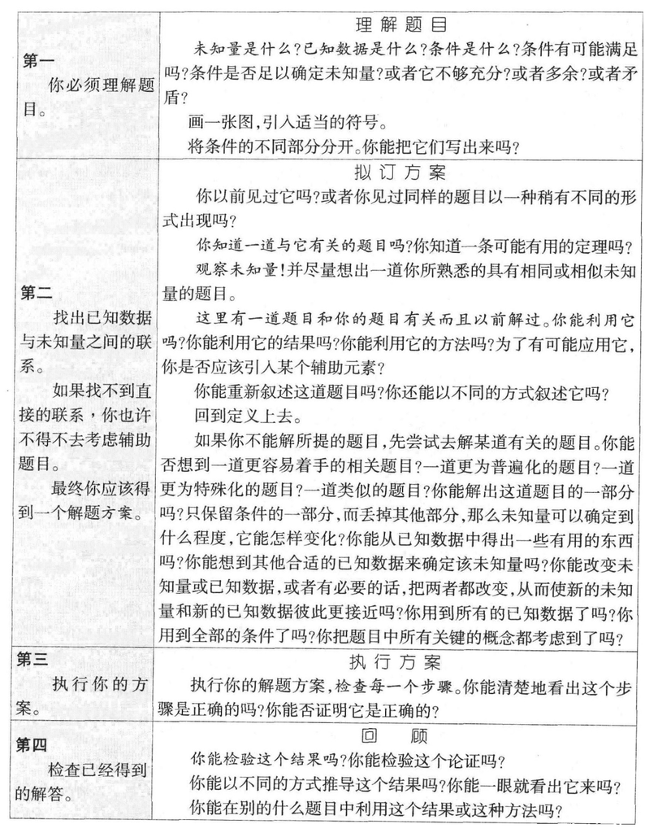

## 一下子就看到答案

在解题思路的最后一部：回顾。它是思考的最重要一步：举一反三。因为在自然科学的大厦中，也是由少数的原型支撑的，这就好比物体由原子构成，原子的类型我们已经发现元素周期表，而发现新的元素越来越难。

回顾的目的，就是以后这个题变化，以不同形式呈现，你就可以轻而易举的辨认出来，一眼就看出解题思路，或者答案。

## 如何猜想

如何猜想？简单说，就是【观察】，观察眼前一套题目，它的规律，它的窍门。

我们应该接受，猜想可以是错误的。就算基于很多事实，但是猜想还是猜想。

### 归纳

归纳就是根据发生的事件，总结其呈现的规律。

### 分解和组合，各个击破

把一个复杂的问题，分解成若干的子问题。不断的分解，直到每个子问题都可以简单的解决。系统的提出这个方法，运用并取得很大的成绩的人是笛卡尔。

### 类比

在一个领域发现的公式，将其应用在其它领域。

### 其它方法

本书，还介绍了很多其它方法进行猜想。比如，使用谚语。可以说是五花八门。在此推荐看原书。

总之，猜想很重要：因为只有能进行猜想，才能成为科学家。科技工作者，无法猜想，恐怕连工程师的工作都无法胜任，更不要说科学家。科学家就是可以对有挑战的科学问题发起猜想，并且能很走上正确方向的人。

## 意志力的作用

数学工作是非常抽象的，但是得到了结论也是最经得起考验的，因为数学非常有逻辑性。在此，波利亚也说明，为什么几何基础是应该学习数学的人，最早去掌握的，是因为数学是逻辑的，以几何入门，可以更简单的掌握逻辑，比如一个空间被一个面分为两个部分，是可以：1）非常精确；2）可见的方式被人理解的。

但是，就像音乐给人的的感受一样，当成功的解题，数学给人以极大的快乐。数学家可以比音乐家更为骄傲的是，数学是大自然的语言。爱因斯坦说，“这个世界最不可思议的地方就是可以被人理解”，而这门语言就是数学。

以前我以为，解题需要一个人有意志力，具备好的数学素质是人的意志力行为的结果。但是最近，在学习了《微积分的力量》 [^5] 、《最佳可能的世界》 [^6] 以及《如何解题》之后，我相信，**对于数学的孜孜以求，这种意志力不是来自于人类的意识，而是宇宙意识**。

道德经第三十四章说“大道泛兮，其可左右。万物恃之而生而不辞，功成不名有。衣养万物而不为主”。所谓，“大道泛兮，其可左右”就是说，每个人或者宇宙，都是被意志包围。如果这种意识的存在，在以前，是一种猜想，那么现在数学就证明了它的存在。

要理解这一点，敬请观赏[《【1379】一直游到太古洪荒 | 解读《2001太空漫游》原著》](https://www.bilibili.com/video/BV1Bd4y1c7os) [^7] 。

**宇宙有强烈的意志，或者我们周围有无数的能量，在引导我们，通过数学认识宇宙。**

[^1]: 如果将获得高分作为最大的目标，那么就会产生：1）忽略了学习数学对人生最有帮助的地方 - 数学是有趣的，可以陶冶人的情操；2）忽略了想要从事任何工作和研究，都需要良好的人际关系，鼓励【高分】就是把竞争放在第一位，以为获得高分就有多了不起了，这样就无法和其它数学家合作，进而取得更大的成绩；3）忽略了真正做好一件事情需要时间，以某次考试的分数作为目标，一旦考试结束，就失去了目标，甚至考试成绩很好，也不会继续学习数学，因为考试结束了，尤其在中国，存在【学而优则仕】的儒家传统。爱因斯坦是一个很好的案例，在学校的时候，他的成绩不好。第一份工作是一个专利局的三级科员，而因为对科学充满了热爱，之后，不断的学习提升，获得了伟大的成就。教育的目的是什么？是找到能热爱一生的兴趣，有的人做出了很大的成绩，有的人没有，但是借助这份兴趣，人生将会更充实，有更多幸福。
[^2]: 能否长期的去做一件事情，是真正的考验。有鉴于最被认为有天赋的莫扎特，也是以最快的速度完成了一万小时的积累，见《异类：不一样的成功启示录》https://item.jd.com/10101297533956.html
[^3]: 波利亚教你如何合理地猜测，https://www.bilibili.com/video/BV1bJ411Y7Ef
[^4]: 林群院士：教科书讲得太复杂，学微积分只需要一个案例，https://www.bilibili.com/video/BV1g4411D7bg
[^5]: 《微积分的力量》购书地址，https://item.jd.com/10026001060386.html
[^6]: 《最佳可能的世界》 购书地址，https://item.jd.com/14413878.html
[^7]: 《【1379】一直游到太古洪荒 | 解读《2001太空漫游》原著》，https://www.bilibili.com/video/BV1Bd4y1c7os

版权声明：自由转载-非商用-非衍生-保持署名 https://hailiang-wang.github.io/ [（创意共享3.0许可证）](https://creativecommons.org/licenses/by-nc-nd/3.0/deed.zh)

//

X

[figure not shown]